# PracticaGeneralResuelta

Jorge A. Martín

17/1/2022

Primero llamo al paquete con `library (palmerpenguins)` (Horst, Hill and Gorman, 2020)y hago un `summary (penguins)`

```
##       species          island    bill_length_mm  bill_depth_mm
##  Adelie   :152   Biscoe   :168   Min.   :32.10   Min.   :13.10
##  Chinstrap: 68   Dream    :124   1st Qu.:39.23   1st Qu.:15.60
##  Gentoo   :124   Torgersen: 52   Median :44.45   Median :17.30
##                                  Mean   :43.92   Mean   :17.15
##                                  3rd Qu.:48.50   3rd Qu.:18.70
##                                  Max.   :59.60   Max.   :21.50
##                                  NA's   :2       NA's   :2
##  flipper_length_mm  body_mass_g       sex           year
##  Min.   :172.0     Min.   :2700   female:165   Min.   :2007
##  1st Qu.:190.0     1st Qu.:3550   male  :168   1st Qu.:2007
##  Median :197.0     Median :4050   NA's  : 11   Median :2008
##  Mean   :200.9     Mean   :4202                Mean   :2008
##  3rd Qu.:213.0     3rd Qu.:4750                3rd Qu.:2009
##  Max.   :231.0     Max.   :6300                Max.   :2009
##  NA's   :2         NA's   :2
```

### Primer ejercicio:

A) Número de individuos totales, masculinos, femeninos y de cada especie

- Número de individuos totales:

`nrow(penguins)`

hay 344 observaciones

- Número de individuos de cada sexo:

`library (dplyr)` (Wickham *et al.*, 2021)

`library (knitr)` (Xie *et al.*, 2021)

`library (kableExtra)` (Zhu *et al.*, 2021)

```r
n_por_sexo <- penguins %>% group_by(sex) %>%
  summarise(sample_size = length(sex))
kable(n_por_sexo, align = "l", caption = "Número de individuos de cada sexo") %>%
  kable_minimal(full_width = F, position="left")
```

Número de individuos de cada sexo

| sex | sample_size |
| --- | --- |
| female | 165 |
| male | 168 |
| NA | 11 |

hay 165 hembras y 168 machos además de 11 individuos sin sexar

- Número de individuos de cada especie

```r
n_por_especie <- penguins %>% group_by(species) %>%
  summarise(sample_size = length(sex))
kable(n_por_especie, align = "l", caption = "Número de individuos de cada especie")%>%
  kable_minimal(full_width = F, position="left")
```

Número de individuos de cada especie

| species | sample_size |
| --- | --- |
| Adelie | 152 |
| Chinstrap | 68 |
| Gentoo | 124 |

hay 152 individuos de la especie adelie, 68 de chinstrap y 124 de gentoo

- Número de individuos de cada especie por sexo

```r
n_por_especie_y_sexo <- penguins %>% group_by(sex, species) %>%
  summarise(sample_size = length(sex))
kable(n_por_especie_y_sexo, align = "l", caption = "Número de individuos de cada grupo")%>%
  kable_minimal(full_width = F, position="left")
```

Número de individuos de cada grupo

| sex | species | sample_size |
| --- | --- | --- |
| female | Adelie | 73 |
| female | Chinstrap | 34 |
| female | Gentoo | 58 |
| male | Adelie | 73 |
| male | Chinstrap | 34 |
| male | Gentoo | 61 |
| NA | Adelie | 6 |
| NA | Gentoo | 5 |

B) La media, desviación estándar, valor mínimo y máximo de la longitud y profundidad del pico, la longitud de la aleta y el tamaño.

```r
variables <- c("long_pico", "prof_pico", "long_aleta", "peso")

media <- c(mean(penguins$bill_length_mm, na.rm = T), mean(penguins$bill_depth_mm, na.rm = T), mean(penguins$flipper_length_mm, na.rm = T), mean(penguins$body_mass_g, na.rm = T))

sd <- c(sd(penguins$bill_length_mm, na.rm = T), sd(penguins$bill_depth_mm, na.rm = T), sd(penguins$flipper_length_mm, na.rm = T), sd(penguins$body_mass_g, na.rm = T))

min <- c(min(penguins$bill_length_mm, na.rm = T), min(penguins$bill_depth_mm, na.rm = T), min(penguins$flipper_length_mm, na.rm = T), min(penguins$body_mass_g, na.rm = T))

max<- c(max(penguins$bill_length_mm, na.rm = T), max(penguins$bill_depth_mm, na.rm = T), max(penguins$flipper_length_mm, na.rm = T), max(penguins$body_mass_g, na.rm = T))

descriptiva <- data.frame(variables,media,sd,min,max)

kable(descriptiva, align = "l", caption = "Estadística descriptiva de las variables")%>%
  kable_minimal(full_width = F, position="left")
```

Estadística descriptiva de las variables

| variables | media | sd | min | max |
| --- | --- | --- | --- | --- |
| long_pico | 43.92193 | 5.459584 | 32.1 | 59.6 |
| prof_pico | 17.15117 | 1.974793 | 13.1 | 21.5 |
| long_aleta | 200.91520 | 14.061714 | 172.0 | 231.0 |
| peso | 4201.75439 | 801.954536 | 2700.0 | 6300.0 |

### Segundo ejercicio:

A) Un gráfico de barras que represente el número de individuos muestreados de cada especie en cada isla, representando las especies en diferentes colores (chinstrap – morado, gentoo – azul, adelie – naranja).

`library (ggplot2)` (Wickham *et al.*, 2021)

```r
subset_especies_isla <-penguins %>% group_by(species, island) %>%
  summarise(n_indiv = length(island))
```

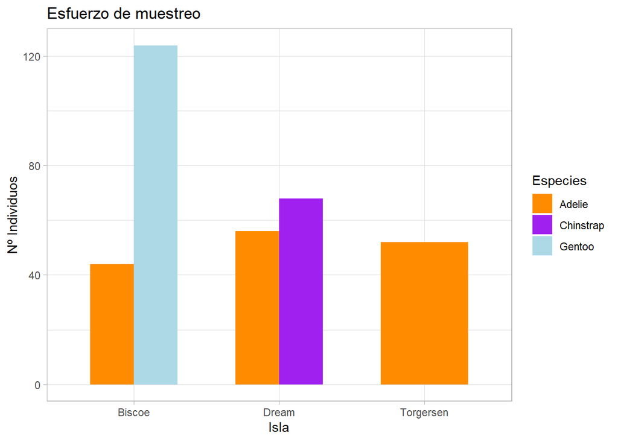

```r
ggplot(data = penguins, aes(x=island, fill=species)) +
  geom_bar(position="dodge", width=0.6) +
  scale_fill_manual(values = c("dark orange", "purple", "light blue")) +
  labs (y="Nº Individuos", x= "Isla") +
  theme_light() +
  ggtitle("Esfuerzo de muestreo") +
  guides (fill = guide_legend(title="Especies"))
```

B) Responde:

- ¿Qué especie se ha muestreado en todas las islas?

Adelie

- ¿Cuántos individuos se han muestreado en la isla Dream?

```r
n_por_islas<-penguins %>% count(island)
kable(n_por_islas, align = "l", caption = "Individuos muestreados por cada isla")%>%
  kable_minimal(full_width = F, position="left")
```

Individuos muestreados por cada isla

| island | n |
| --- | --- |
| Biscoe | 168 |
| Dream | 124 |
| Torgersen | 52 |

Se muestrearon 124 individuos en la isla Dream

### Tercer ejercicio:

A) Gráfico multipanel de cajas y bigotes con el tamaño de los pingüinos sgún su sexo, en cada panel una especie.

Necesito el paquete patchwork `library(patchwork)`(Pedersen, 2020)

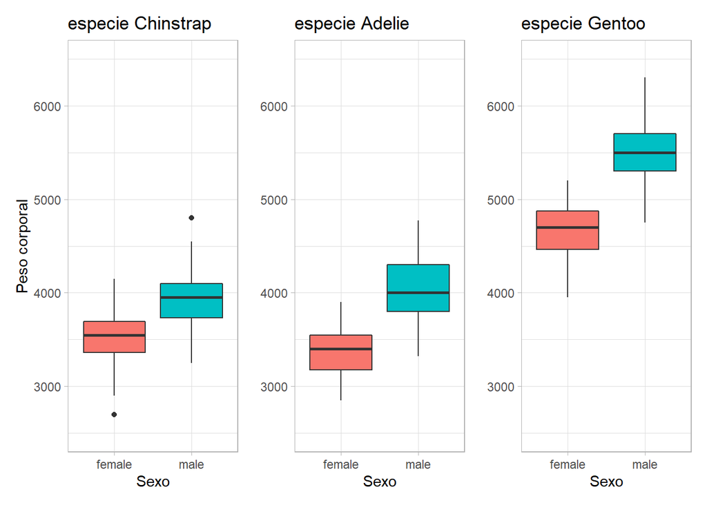

```r
pingus_adelie <- penguins %>% filter( species =="Adelie") %>% na.omit()
box_adelie<-ggplot(data = pingus_adelie, aes(x=sex, y=body_mass_g, fill=sex)) +
geom_boxplot(width = 0.8) +
  theme_light() +
  labs(y= element_blank(), x="Sexo") +
  ggtitle("especie Adelie") +
  theme(legend.position = "none") +
  coord_cartesian(ylim = c(2500,6500))

pingus_chinstrap <- penguins %>% filter(species == "Chinstrap") %>% na.omit()
box_chinstrap<-ggplot(data = pingus_chinstrap, aes(x=sex, y=body_mass_g, fill=sex)) +
  geom_boxplot(width = 0.8) +
  theme_light() +
  labs( x="Sexo", y= "Peso corporal") +
  ggtitle("especie Chinstrap") +
  theme(legend.position = "none")+
  coord_cartesian(ylim = c(2500,6500))

pingus_gentoo <- penguins %>% filter( species == "Gentoo") %>% na.omit()
box_gentoo<-ggplot(data = pingus_gentoo, aes(x=sex, y=body_mass_g, fill=sex)) +
  geom_boxplot(width = 0.8) +
  theme_light() +
  labs( x="Sexo", y=element_blank()) +
  ggtitle("especie Gentoo") +
  theme(legend.position = "none")+
  coord_cartesian(ylim = c(2500,6500))

box_chinstrap + box_adelie + box_gentoo
```

B) Contesta:

- ¿Qué especie tiene mayor tamaño?

la especie Gentoo

- ¿En qué especie hembras y machos tienen tamaños similares?

en la especie Chinstrap

### Referencias

Horst, A., Hill, A. and Gorman, K. (2020) *Palmerpenguins: Palmer archipelago (antarctica) penguin data. R package version 0.1.0.* Available at: https://allisonhorst.github.io/palmerpenguins/.

Pedersen, T.L. (2020) *Patchwork: The composer of plots*. Available at: https://CRAN.R-project.org/package=patchwork.

Wickham, H. *et al.* (2021) *ggplot2: Create elegant data visualisations using the grammar of graphics*. Available at: https://CRAN.R-project.org/package=ggplot2.

Xie, Y. *et al.* (2021) *Knitr: A general-purpose package for dynamic report generation in r*. Available at: https://CRAN.R-project.org/package=knitr.

Zhu, H. *et al.* (2021) *kableExtra: Construct complex table with ’kable’ and pipe syntax*. Available at: https://CRAN.R-project.org/package=kableExtra.